# Airline On-Time Performance Data, US 2008

## by Sarah Akinkunmi

## Introduction

This dataset reports flights in the United States, including carriers, arrival and departure delays, and reasons for delays, for year 2008. It contains more than 2 million records and 29 features.

## Summary of findings

2008 flights in the USA from January to April were mostly earlier than expected on right on time. The delays were mostly caused by late aircrafts and then National Airspace System (NAS) delays, although we find out that NAS delay have the strongest relationship with delay times. This flights mostly covered short distances, however, there was no relationship between the distances and delayed times. The most common destinations for flights were the same as the departure states. Northwest Airlines Inc. (NW) have the most average delays. Lastly, delay times and NAS delays have a strong relationship for each of the major destinations in each month.

The questions I generated insights on are:

- How are delay times distributed? Are many flights were delayed or not?
- What is the major cause of delay?
- Were the flights over more longer distances than short distances?
- What are the top destinations and origins for the flights?
- Does distance affect delay times?
- Do some airlines experience more delays than others?
- What is the relationship between delay times and the causes of delay?
- How do the delay times and NAS delay vary with the most common destinations in each month?

## Data Wrangling

Issues that are corrected

- Combining `Year`, `Month` and `DayofMonth` columns into one
- Removing unnecessary columns
- Dropping duplicate rows, if any

## Data Explorations and Explanations

## Question: How are delay times distributed? Are many flights were delayed or not?

More than 100,000 flights were earlier than expected and long delays over 50 minutes are less frequent.

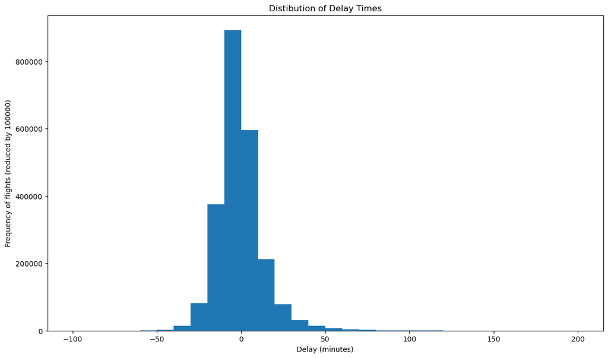

## Question: What type of delay caused the most delays?

Late aircrafts are the most common delay causes followed by the National Airport System delays. Security delays are the least common cause of delays.

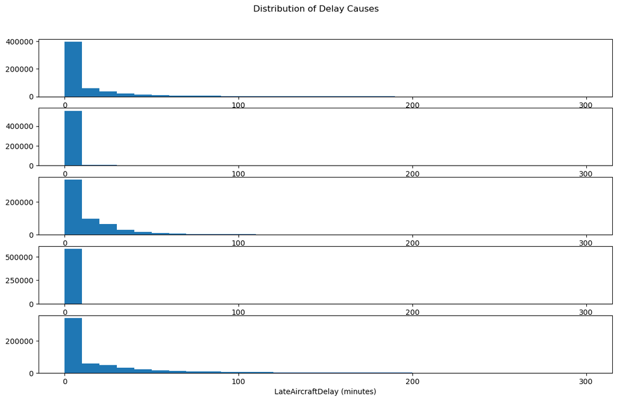

## Question: Were the flights over more longer distances than short distances?

Most flights covered short distances (< 1000 miles)

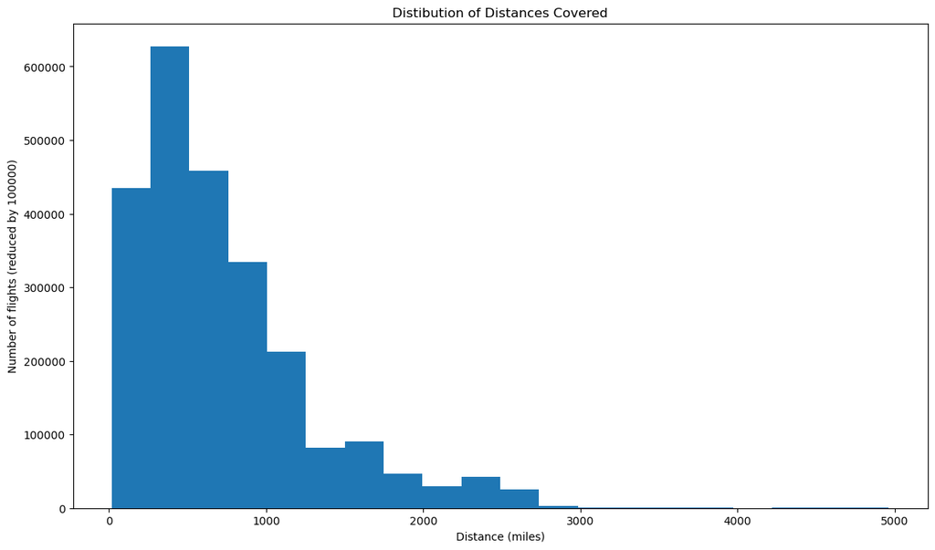

## Question: What are the top destinations and origins for the flights?

Atlanta is the state most flights fly from return to. Comparing the visualizations, the top 10 states are the same.

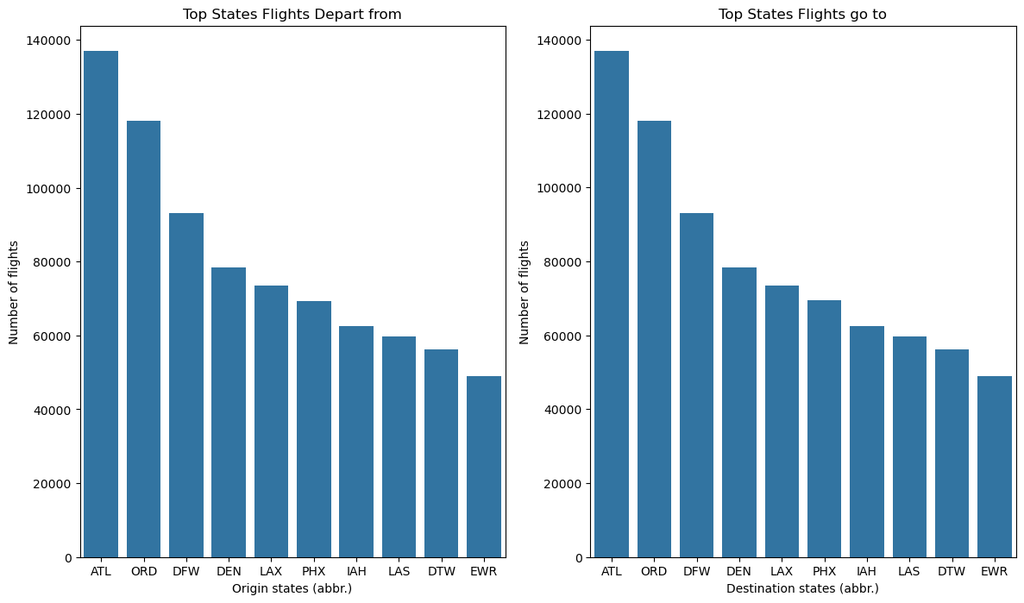

## Question: Does distance affect delay times?

There is a slight negative correlation between delay and distance

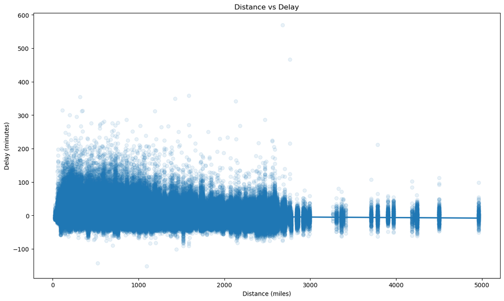

## Question: Do some airlines experience more delays than others?

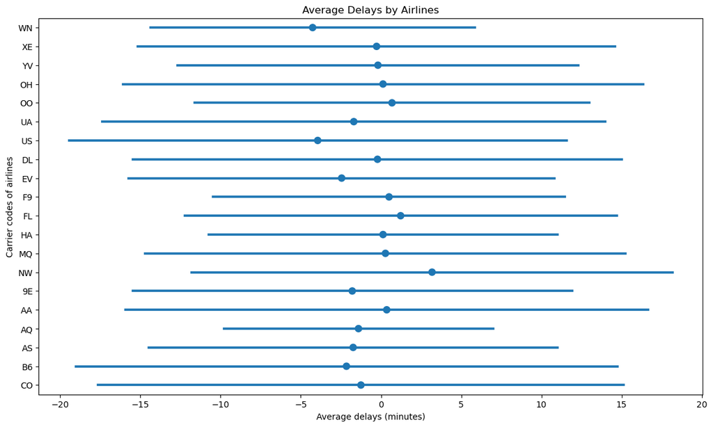

## Question: What is the relationship between delay times and the causes of delay?

NAS Delays are within the control of the National Airspace System and may include: non-extreme weather conditions, airport operations, heavy traffic volume, air traffic control, etc. Delays that occur after Actual Gate Out are usually attributed to the NAS and are also reported through OPSNET. (https://aspm.faa.gov/aspmhelp/index/Types_of_Delay.html). Therefore, it is more likely for these to cause long delays depending on the severity of the issue.

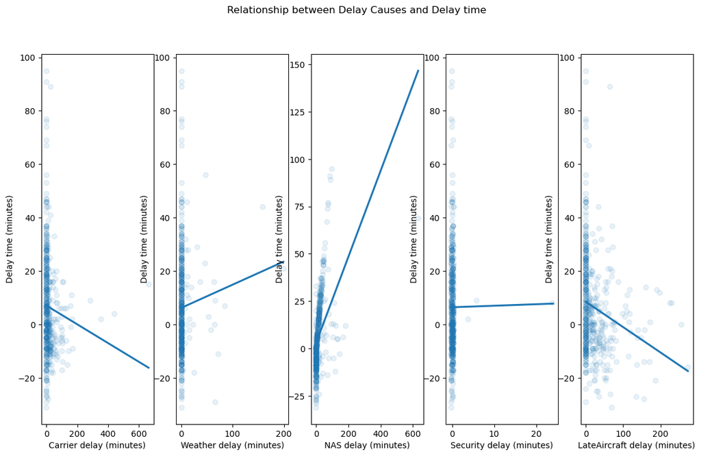

## Question: How do the delay times and NAS delay vary with the most common destinations in each month?

There is a positive correlation between delay time and NAS delay for the top destinations in each month, further strengthening the narrative that NAS delays affect the delay times.

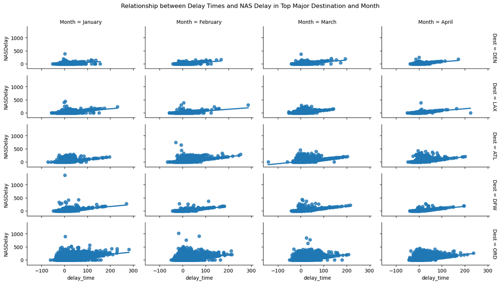